# TP1 - SADM - G2 - Report

EL FARISSI Tarik, OUMAR Isselmou, WEBER Marthyna Luiza

2023-02-06

## Exercise 1: Preliminary analysis of the data

To read the data set into a data frame object, we used:

```r
prostateCancer <- read.table("prostate.data", header=T)
attach(prostateCancer)
```

To remove the last column of the data frame, we used:

```r
prostateCancer <- subset(prostateCancer, select = -c(train))
```

To visualize the correlations between all the variables, we used:

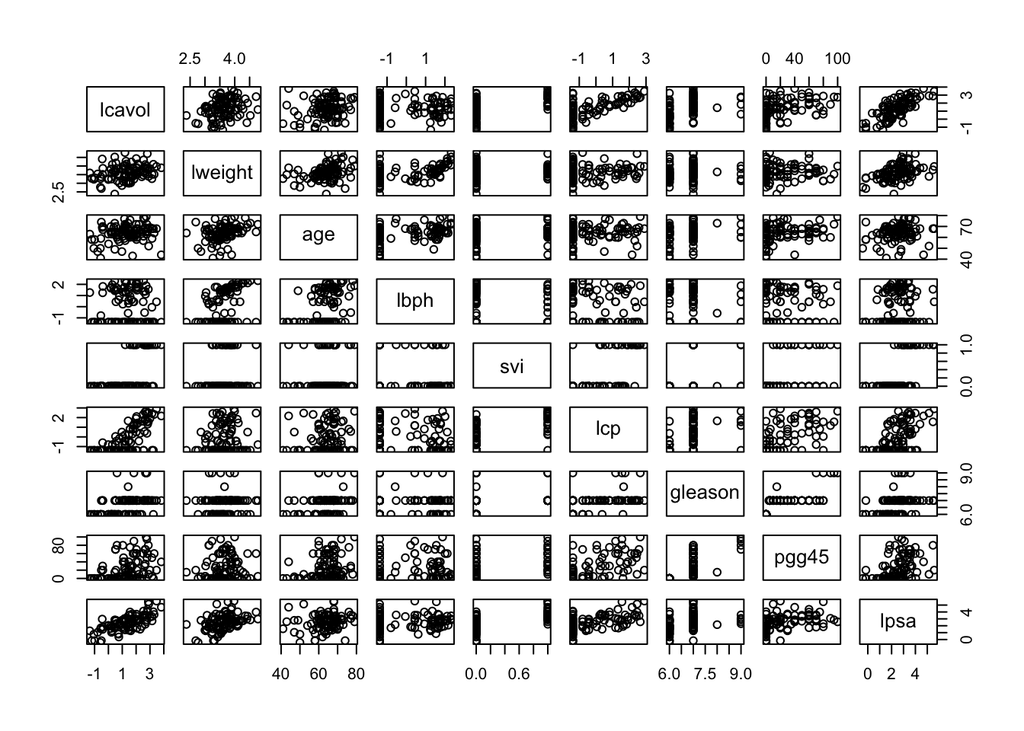

```r
pairs(prostateCancer)
```

We can notice the positive correlation between:

- `lcavol` (the logarithm of the tumor volume) and `lpsa` (the log of a prostate specific antigen),
- `lcavol` and `lcp` (the log of capsular penetration),
- `lweigth` (the log of prostate weight) and `age` (the age of the patient),
- `lweigth` and `lbph` (the log of benign prostatic hyperplasia amount),
- `lweigth` and `lpsa`,
- `lcp` and `lpsa`,
- `pgg45` (the percent of Gleason scores 4 or 5) and `lpsa`.

Therefore, the variables most related to `lcavol` are `lpsa` and `lcp`.

## Exercise 2: Linear regression

### a) Multiple linear regression

To consider the variables `gleason` and `svi` as qualitative variables, we used:

```r
prostateCancer$gleason<-factor(prostateCancer$gleason)
prostateCancer$svi<-factor(prostateCancer$svi)
```

To create and display multiple linear regression for the `lcavol` variable from the given data set, we used:

```r
model <- lm(lcavol ~., data = prostateCancer)
summary(model)
```

```
##
## Call:
## lm(formula = lcavol ~ ., data = prostateCancer)
##
## Residuals:
##      Min       1Q   Median       3Q      Max
## -1.91436 -0.48444 -0.02664  0.54915  1.80062
##
## Coefficients:
##              Estimate Std. Error t value Pr(>|t|)
## (Intercept) -1.406654   0.874455  -1.609   0.1114
## lweight     -0.011246   0.211453  -0.053   0.9577
## age          0.024782   0.011241   2.205   0.0301 *
## lbph        -0.104200   0.058209  -1.790   0.0770 .
## svi1        -0.220419   0.256351  -0.860   0.3923
## lcp          0.402760   0.085074   4.734 8.58e-06 ***
## gleason7     0.311676   0.215268   1.448   0.1513
## gleason8    -0.710588   0.758827  -0.936   0.3517
## gleason9     0.790135   0.487510   1.621   0.1087
## pgg45       -0.009444   0.004540  -2.080   0.0405 *
## lpsa         0.549573   0.090093   6.100 2.94e-08 ***
## ---
## Signif. codes:  0 '***' 0.001 '**' 0.01 '*' 0.05 '.' 0.1 ' ' 1
##
## Residual standard error: 0.6973 on 86 degrees of freedom
## Multiple R-squared:  0.6865, Adjusted R-squared:   0.65
## F-statistic: 18.83 on 10 and 86 DF,  p-value: < 2.2e-16
```

The lines starting with `svi` and `gleason` are dummy variables that represent the categorical variables with the same name. The variable `svi` has only one related dummy variable, `svi1`, which represents true values for the seminal vesicle invasion in the model. The variable `gleason` has three dummy variables related to it, `gleason7`, `gleason8` and `gleason9`. With the following command, we can see the coding that R has used to create these dummy variables:

```r
contrasts(prostateCancer$gleason)
```

```
##   7 8 9
## 6 0 0 0
## 7 1 0 0
## 8 0 1 0
## 9 0 0 1
```

We can see that there is no `gleason6` (event though the value 6 appears a lot for the `gleason` variable), because 6 corresponds to the situation where all the three `gleason` dummy variables are 0. Generally, a qualitative variable with n levels (in this case we have 4 levels, corresponding to values 6, 7, 8 and 9) will be transformed into n-1 variables each with two levels. These n-1 new variables contain the same information than the single variable.

In the results, we can see that the p-value of the F-statistic is < 2.2e-16, a significant value, which means that one of the parameter variables has a strong relation to `lcavol`.

Also, the t-value for the variables `lpsa` and `lcp` is significantly higher than the other t-values, which indicates that there is a significant association between them and `lcavol` (as confirmed by the pairs plotted above).

### b) Confidence intervals

The confidence interval of level 95% can be given to out model by simply calling the following command, since the default value for it is already 95%:

```r
confint(model)
```

```
##                    2.5 %        97.5 %
## (Intercept) -3.145013212  0.3317051396
## lweight     -0.431599858  0.4091074596
## age          0.002435876  0.0471289533
## lbph        -0.219914296  0.0115152113
## svi1        -0.730029034  0.2891903039
## lcp          0.233638987  0.5718802443
## gleason7    -0.116263131  0.7396155044
## gleason8    -2.219087210  0.7979107787
## gleason9    -0.179003633  1.7592727371
## pgg45       -0.018468522 -0.0004191483
## lpsa         0.370473639  0.7286725619
```

A confidence interval is a range of values that is likely to contain the value of a parameter variable. It gives us a margin of error around the estimated value to help us understand how wrong the estimate might be. In this case, we can say with 95% of confidence that the values for the `lweigth` regression coefficient will always fall between -0.431599858 and 0.4091074596, the values for the `age` regression coefficient will fall between 0.002435876 and 0.0471289533 and so forth.

### c) `lpsa` variable

When we remove the `lpsa` variable from the model, using:

```r
model1 <- update(model, ~. -lpsa)
summary(model1)
```

```
##
## Call:
## lm(formula = lcavol ~ lweight + age + lbph + svi + lcp + gleason +
##     pgg45, data = prostateCancer)
##
## Residuals:
##      Min       1Q   Median       3Q      Max
## -1.75335 -0.44146 -0.04185  0.43024  2.30973
##
## Coefficients:
##              Estimate Std. Error t value Pr(>|t|)
## (Intercept) -1.632413   1.039711  -1.570   0.1200
## lweight      0.475057   0.233069   2.038   0.0446 *
## age          0.017315   0.013298   1.302   0.1963
## lbph        -0.077223   0.069071  -1.118   0.2666
## svi1         0.270430   0.289652   0.934   0.3531
## lcp          0.478911   0.100146   4.782 7.01e-06 ***
## gleason7     0.646423   0.247716   2.610   0.0107 *
## gleason8    -0.639702   0.902935  -0.708   0.4805
## gleason9     1.103664   0.576927   1.913   0.0590 .
## pgg45       -0.009670   0.005402  -1.790   0.0769 .
## ---
## Signif. codes:  0 '***' 0.001 '**' 0.01 '*' 0.05 '.' 0.1 ' ' 1
##
## Residual standard error: 0.8298 on 87 degrees of freedom
## Multiple R-squared:  0.5508, Adjusted R-squared:  0.5043
## F-statistic: 11.85 on 9 and 87 DF,  p-value: 5.605e-12
```

Going further, for the confidence interval of the `lpsa` predictor, we can say with 95% of confidence that each unitary increment in the log of a prostate specific antigen will cause an increase of at least 0.370473639 and at most 0.7286725619 in the log of the tumor volume, which is a significant increase in comparison to those of the other predictor used in the model.

### d) Residuals

To obtain the predicted values for the `lcavol` variable, based on the predictor variables, we used the `predict()` function:

```r
predicted <- predict(model)
```

Then, we create a scatter plot of the predicted values against the actual values using the `plot()` function, specifying the actual values as the x-axis and the predicted values as the y-axis:

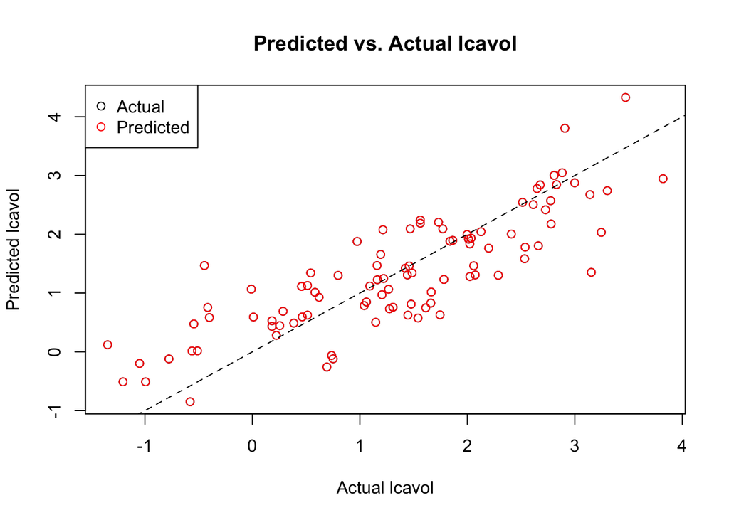

```r
plot(prostateCancer$lcavol, predicted, main = "Predicted vs. Actual lcavol", xlab = "Actual lcavol", ylab = "Predicted lcavol")
points(prostateCancer$lcavol, predicted, col = "red")
abline(0, 1, lty = 2)
legend("topleft", legend = c("Actual", "Predicted"), col = c("black", "red"), pch = 1)
```

To plot the histogram of residuals for this model, we first calculate the residuals for the model using the `residuals()` function:

```r
residuals <- residuals(model)
```

Then, we create a histogram of the residuals using the `hist()` function:

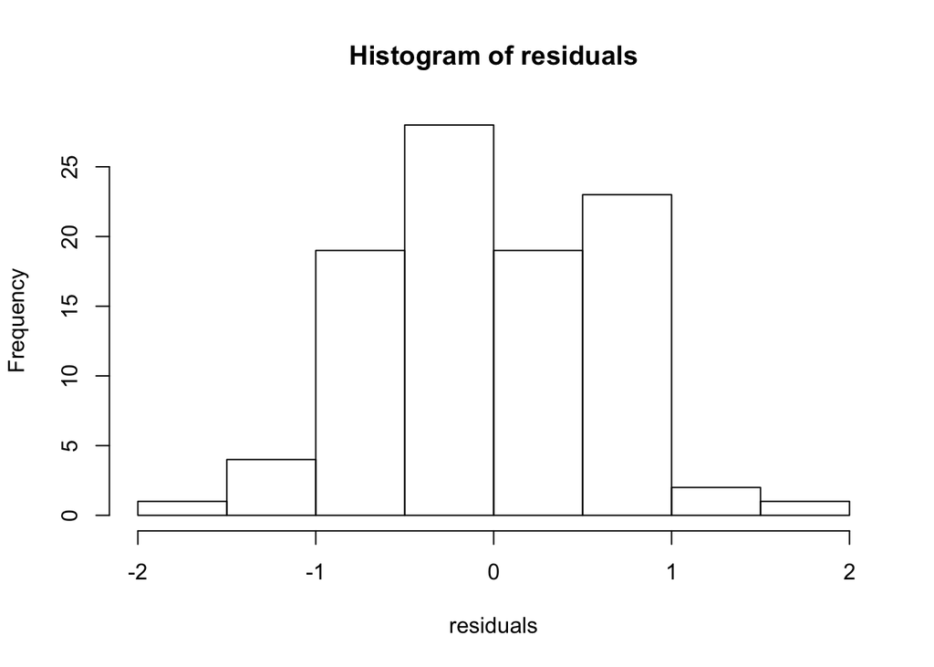

```r
hist(residuals)
```

We can assume that the residuals are normally distributed because the mean is approximately 0 and the histogram has a roughly symmetric shape.

To compute the residual sum of squares (RSS) of our model, we used:

```r
RSS <- sum(residuals^2)
RSS
```

```
## [1] 41.81407
```

### e) Model optimality

The overall quality of the model can be stated by examining the R-squared and Residual standard error. The R-squared corresponds to the correlation coefficient between the observed values for the outcome `lcavol` and its predicted values. The R-squared value of 0.65 of the model shows that it explains a reasonable portion of the variance in `lcavol`, but it could be improved.

The Residual standard error estimate gives a measure of error of prediction. The lower it is, the more accurate the model, so a value of 0.69 indicates that our model could be better than it currently is.

### f) Removing `lpsa` and `lcp` predictors

The new model is obtained with:

```r
model2 <- lm(lcavol ~ . - lpsa - lcp, data = prostateCancer)
summary(model2)
```

```
##
## Call:
## lm(formula = lcavol ~ . - lpsa - lcp, data = prostateCancer)
##
## Residuals:
##      Min       1Q   Median       3Q      Max
## -1.84488 -0.48256 -0.01752  0.58918  2.21990
##
## Coefficients:
##               Estimate Std. Error t value Pr(>|t|)
## (Intercept) -1.9717103  1.1590310  -1.701 0.092442 .
## lweight      0.5849583  0.2591548   2.257 0.026472 *
## age          0.0072858  0.0146727   0.497 0.620739
## lbph        -0.0746433  0.0771750  -0.967 0.336097
## svi1         1.0245817  0.2714729   3.774 0.000291 ***
## gleason7     0.8007406  0.2744312   2.918 0.004473 **
## gleason8     0.6868720  0.9601171   0.715 0.476253
## gleason9     1.1726480  0.6444380   1.820 0.072214 .
## pgg45       -0.0004312  0.0056372  -0.076 0.939203
## ---
## Signif. codes:  0 '***' 0.001 '**' 0.01 '*' 0.05 '.' 0.1 ' ' 1
##
## Residual standard error: 0.9272 on 88 degrees of freedom
## Multiple R-squared:  0.4327, Adjusted R-squared:  0.3811
## F-statistic:  8.39 on 8 and 88 DF,  p-value: 2.11e-08
```

Now, our new model has a much higher p-value and a much higher RSE, which indicates that the removal of the `lpsa` and `lcp` predictors caused a decrease in the model’s quality, so we can assume that they are strongly related to the `lcavol` outcome.

When we remove the `lpsa` and `lcp` columns from our model, it means that it is using fewer predictors to make the prediction. This results in a reduction of the amount of information that the model is using to make its prediction. As a result, the model is now less accurate in predicting the response variable `lcavol.`

We say that the model is less accurate because we observed higher values for the RSE, which is a measure of the amount of variance in the residuals (difference between predicted and actual values) of the model. The RSE measures the spread of the residuals around the regression line, and as the spread of the residuals increases, the RSE also increases.

Similarly, when we remove these variables from the model, the p-values of the remaining predictors changed. This is because the p-values measure the significance of each predictor variable in the presence of all the other predictor variables. Removing a variable can change the relationship between the other variables and the response variable, leading to changes in the significance of the remaining variables.

## Exercise 3: Best subset selection

A regression model that uses k predictors is said to be of size k. For instance, `lcavol = β1 lpsa + β0 + ε` and `lcavol = β1 lweight + β0 + ε` are models of size 1. The regression model without any predictor `lcavol = β0 + ε` is a model of size 0. The goal of this exercise is to select the best model of size k for each value of `k in {0...8}`.

### a) Describing the implemented models

The model implemented by the object of this `summary` call:

```r
summary(lm(lcavol~1, data=prostateCancer))
```

```
##
## Call:
## lm(formula = lcavol ~ 1, data = prostateCancer)
##
## Residuals:
##      Min       1Q   Median       3Q      Max
## -2.69708 -0.83719  0.09691  0.77703  2.47099
##
## Coefficients:
##             Estimate Std. Error t value Pr(>|t|)
## (Intercept)   1.3500     0.1197   11.28   <2e-16 ***
## ---
## Signif. codes:  0 '***' 0.001 '**' 0.01 '*' 0.05 '.' 0.1 ' ' 1
##
## Residual standard error: 1.179 on 96 degrees of freedom
```

is a very simple linear regression model that only includes an intercept term. We are regressing the response variable `lcavol` against one single predictor, which is simply a constant. Here, we are assuming that `lcavol` is a constant value for all observations. This model is equivalent to simply calculating the mean of `lcavol`, and can be used as a baseline model to compare against more complex models but it is not very useful for making accurate predictions. The RSE is high, which also indicates that this is not an useful model.

Here we can see that we approach `lcavol` by the mean, and we get the same value as the model above, since it’s a model of size 0 : `lcavol = 1.35 + eps`

```r
mean(prostateCancer$lcavol)
```

```
## [1] 1.35001
```

The model implemented by the object of this `summary` call:

```r
summary(lm(lcavol~., data=prostateCancer[,c(1,4,9)]))
```

```
##
## Call:
## lm(formula = lcavol ~ ., data = prostateCancer[, c(1, 4, 9)])
##
## Residuals:
##     Min      1Q  Median      3Q     Max
## -2.2998 -0.6245  0.0414  0.5564  1.6266
##
## Coefficients:
##             Estimate Std. Error t value Pr(>|t|)
## (Intercept) -0.54900    0.19459  -2.821  0.00583 **
## lbph        -0.08791    0.05709  -1.540  0.12697
## lpsa         0.76979    0.07176  10.728  < 2e-16 ***
## ---
## Signif. codes:  0 '***' 0.001 '**' 0.01 '*' 0.05 '.' 0.1 ' ' 1
##
## Residual standard error: 0.7983 on 94 degrees of freedom
## Multiple R-squared:  0.5508, Adjusted R-squared:  0.5412
## F-statistic: 57.62 on 2 and 94 DF,  p-value: < 2.2e-16
```

And the model implemented by the object of this `summary` call:

```r
summary(lm(lcavol~., data=prostateCancer[,c(1,2,9)]))
```

```
##
## Call:
## lm(formula = lcavol ~ ., data = prostateCancer[, c(1, 2, 9)])
##
## Residuals:
##      Min       1Q   Median       3Q      Max
## -2.06980 -0.60231  0.05406  0.53762  1.70037
##
## Coefficients:
##             Estimate Std. Error t value Pr(>|t|)
## (Intercept) -0.09570    0.71596  -0.134    0.894
## lweight     -0.12781    0.21327  -0.599    0.550
## lpsa         0.77047    0.07915   9.734 6.75e-16 ***
## ---
## Signif. codes:  0 '***' 0.001 '**' 0.01 '*' 0.05 '.' 0.1 ' ' 1
##
## Residual standard error: 0.8068 on 94 degrees of freedom
## Multiple R-squared:  0.5412, Adjusted R-squared:  0.5314
## F-statistic: 55.44 on 2 and 94 DF,  p-value: < 2.2e-16
```

### b) Residual sums of squares

Compute the residual sums of squares for all models of size `k = 2`. What is the best choice of 2 predictors among 8?

Firstly, we get names of predictor variables:

```r
names <- names(prostateCancer)[2:9]
```

Then, we initialize a vector to store the RSS for each model:

```r
RSS <- numeric(choose(length(names), 2))
```

The length of RSS is the total number of possible combinations of two variables in this model. We then iterate through all possible combinations of two variables with:

```r
k <- 1

for (vars in combn(names, 2, simplify = FALSE)) {
  formula <- as.formula(paste("lcavol ~", paste(vars, collapse = " + ")))
  model <- lm(formula, data = prostateCancer)
  RSS[k] <- sum(model$residuals^2)
  cat("Vars= ", vars, " index= ", k, "\n")
  k <- k + 1
}
```

```
## Vars=  lweight age  index=  1
## Vars=  lweight lbph  index=  2
## Vars=  lweight svi  index=  3
## Vars=  lweight lcp  index=  4
## Vars=  lweight gleason  index=  5
## Vars=  lweight pgg45  index=  6
## Vars=  lweight lpsa  index=  7
## Vars=  age lbph  index=  8
## Vars=  age svi  index=  9
## Vars=  age lcp  index=  10
## Vars=  age gleason  index=  11
## Vars=  age pgg45  index=  12
## Vars=  age lpsa  index=  13
## Vars=  lbph svi  index=  14
## Vars=  lbph lcp  index=  15
## Vars=  lbph gleason  index=  16
## Vars=  lbph pgg45  index=  17
## Vars=  lbph lpsa  index=  18
## Vars=  svi lcp  index=  19
## Vars=  svi gleason  index=  20
## Vars=  svi pgg45  index=  21
## Vars=  svi lpsa  index=  22
## Vars=  lcp gleason  index=  23
## Vars=  lcp pgg45  index=  24
## Vars=  lcp lpsa  index=  25
## Vars=  gleason pgg45  index=  26
## Vars=  gleason lpsa  index=  27
## Vars=  pgg45 lpsa  index=  28
```

```r
which.min(RSS)
```

```
## [1] 25
```

The `combn()` function generates all possible combinations of two variables from the set of predictor variable `names` and stores each combination in the `vars` variable. We first construct the formula object for the current combination of variables using the `paste()` and `as.formula()` functions. Then, we fit the linear regression model for the current combination of variables and use it to compute the RSS for the current model and store it in the RSS vector.

With `which.min(RSS)` we can see that the pair that minimizes the RSS for a model of size 2 is `lcp` and `lpsa`, as suspected.

### c) Predictors that minimize the residual sum of squares

We used:

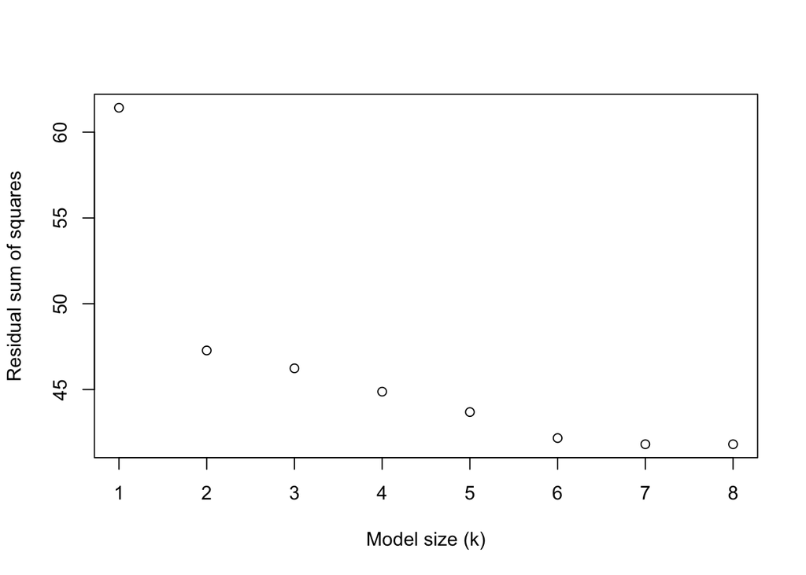

```r
library(leaps)

# Initialize the list of optimal predictors for each model size and the scope of k
optimal_predictors <- list()
k_vals <- 1:8

# Loop over each model size and find the optimal set of predictors
for (k in k_vals) {
  # Get all combinations of k predictors
  combos <- combn(names(prostateCancer)[-1], k)

  # Initialize the matrix of RSS values for each combination
  rss <- matrix(NA, nrow = ncol(combos), ncol = 1)

  # Loop over each combination of predictors and compute the RSS
  for (i in seq_along(rss)) {
    formula <- as.formula(paste("lcavol ~", paste(combos[, i], collapse = " + ")))
    lm_fit <- lm(formula, data = prostateCancer)
    rss[i] <- sum(lm_fit$residuals^2)
  }

  # Get the index of the combination with the lowest RSS
  idx_min <- which.min(rss)

  # Store the optimal predictors for this model size
  optimal_predictors[[k]] <- combos[, idx_min]
}


# Plot the RSS as a function of k
 rss_vals <- sapply(optimal_predictors, function(preds) {
   if(length(preds) > 0) {
     formula <- as.formula(paste("lcavol ~", paste(preds, collapse = " + ")))
     lm_fit <- lm(formula, data = prostateCancer)
     sum(lm_fit$residuals^2)
   }
 })
# adding the intercept
optimal_predictors <- c(1, optimal_predictors)

plot(k_vals, rss_vals, xlab = "Model size (k)", ylab = "Residual sum of squares")
```

We get:

```r
n_models <- 0:8
for (k in n_models) {
  cat("k = ", k, ": ", optimal_predictors[[k+1]], "\n")
}
```

```
## k =  0 :  1
## k =  1 :  lpsa
## k =  2 :  lcp lpsa
## k =  3 :  age lcp lpsa
## k =  4 :  age lbph lcp lpsa
## k =  5 :  age lcp gleason pgg45 lpsa
## k =  6 :  age lbph lcp gleason pgg45 lpsa
## k =  7 :  age lbph svi lcp gleason pgg45 lpsa
## k =  8 :  lweight age lbph svi lcp gleason pgg45 lpsa
```

### d) Selecting optimal regression model size

One limitation of RSS is that it only considers the performance of the model on the training data and does not take into account the model’s performance on new, unseen data. Therefore, a model that minimizes RSS may still overfit to the training data and perform poorly on new data. So, we should always consider the model’s generalization performance on new, unseen data using techniques such as cross-validation.

Side note: overfitting occurs when a model is trained on a dataset to such an extent that it becomes too specialized to the training data and does not generalize well to new data. This can happen when a model is too complex or has too many parameters relative to the size of the training data.

## Exercise 4: Split-validation

### a) Brief overview of split-validation

The basic idea behind split-validation is to divide the dataset into two parts: a training set and a validation set. The training set is used to train the model, while the validation set is used to evaluate the performance of the model. The goal of split-validation is to assess how well the model can generalize to new, unseen data. In the question (c) of the third exercise, we are trying to find the best predictors for different model sizes, this involves modifying the model itself for every size, in comparison, split-validation focuses on evaluating the performance of the model as it is, using a held-out validation set that is independent of the training set.

### b) Validation set

```r
# Creating a vector containing all the index numbers from 1 to 97
index <- seq(1, 97)

# Using modulus operator to identify the indices that are a multiple of 3
valid <- index[index %% 3 == 0]
```

### c) Mean training error

```r
# Had to use this vector because the "!valid" was returning an error.
train <- setdiff(index, valid)

# The model
training_model <- lm(lcavol~., data = prostateCancer[train, c(1,6, 9)])

# By running this code we want to fit a linear regression model with lcavol as the dependent variable and all other available predictor variables as the independant variables: "lcavol ~ ." and we want to only include the training observations that are not in the validation set: "!valid".

## Mean training error for the model

## Predicting the outcome variable for the training data
lcavol_predict <- predict(training_model, newdata = prostateCancer[train, c(1,6, 9)])

## Calculating the difference between the predicted values and the actual values for the training data
errors <- lcavol_predict -  prostateCancer[train, c(1,6, 9)]$lcavol

## Calculating the mean traing error
mean_training_error <- mean((errors)^2)
```

### d) Predicting values in the validation set

```r
# Predicting the outcome variable for the validation data
lcavol_predict_val <- predict(training_model, prostateCancer[valid, c(1,6, 9)])

# Calculating the mean prediction error
mean_prediction_error <- mean((lcavol_predict_val - prostateCancer[valid, c(1, 6, 9)]$lcavol)^2)

# Printing the mean prediction and training error
cat("Mean prediction error: ", mean_prediction_error, "\nMean training error: ", mean_training_error)
```

```
## Mean prediction error:  0.5672302
## Mean training error:  0.4616663
```

### e) Performing split-validation

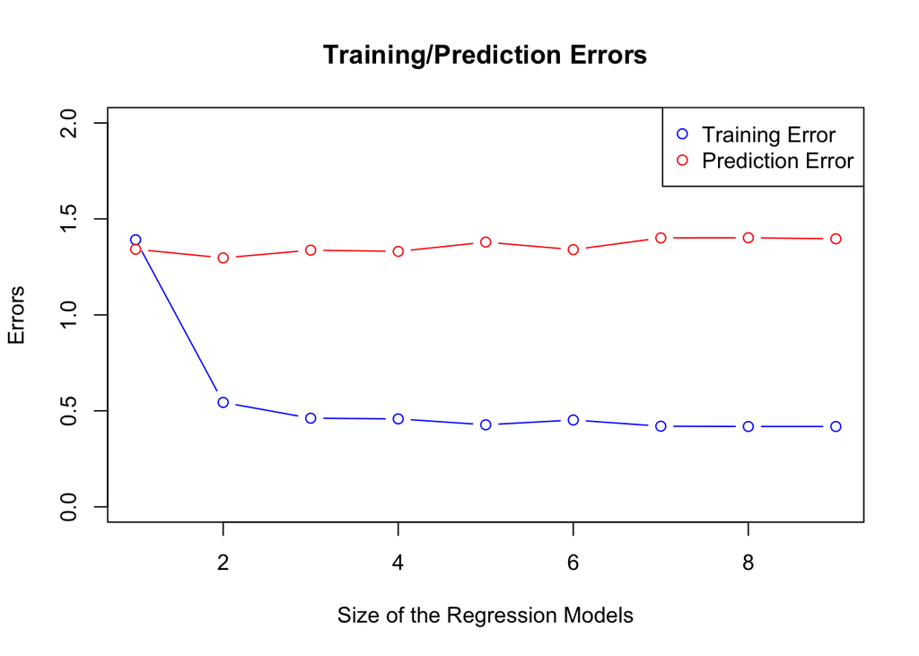

```r
## Defining the model sizes to consider
model_sizes <- seq(2, 9)

# Initializing vectors to store the training and prediction errors for each model size
training_errors <- rep(0, length(model_sizes))
prediction_errors <- rep(0, length(model_sizes))

# Looping through each model size
for (i in model_sizes) {
  ## Geting the predictor set for the current model size
  predictors <- optimal_predictors[[i]]

  ## Geting the subset of data with the valid indices and the current predictor set
  train_subset <- prostateCancer[train, c("lcavol", predictors)]

  ## Fitting the model on the training subset
  training_model <- lm(lcavol ~ ., data = train_subset)

  ## Computing the training error
  fitted_values <- predict(training_model, new_data = train_subset)
  training_error <- mean((train_subset$lcavol - fitted_values)^2)

  ## Computing the prediction error on the validation set
  validation_subset <- prostateCancer[valid, c("lcavol", predictors)]
  fitted_values_val <- predict(training_model, new_data = validation_subset)
  prediction_error <- mean((validation_subset$lcavol - fitted_values_val[1:32])^2)

  ## Storing the errors for the current model size
  training_errors[i] <- training_error
  prediction_errors[i] <- prediction_error
}

intercept_model <- lm(lcavol~1, data=prostateCancer[train,])
# Computing the training error for the intercept model
train_pred <- predict(intercept_model, newdata = prostateCancer[train, ])
train_error_intercept <- mean((prostateCancer$lcavol[train] - train_pred)^2)

# Computing the prediction error
valid_pred <- predict(intercept_model, newdata = prostateCancer[valid, ])
valid_error_intercept <- mean((prostateCancer$lcavol[valid] - valid_pred)^2)

training_errors[1] <- train_error_intercept
prediction_errors[1] <- valid_error_intercept

model_sizes <- 1:9
# Ploting the errors as a function of the regression model size
plot(model_sizes, training_errors, type = "b", col = "blue", ylim = c(0, 2),
     xlab = "Size of the Regression Models", ylab = "Errors", main = "Training/Prediction Errors")
lines(model_sizes, prediction_errors, type = "b", col = "red")
legend("topright", legend = c("Training Error", "Prediction Error"),
       col = c("blue", "red"), pch = 1)
```

```r
best_model_idx <- which.min(abs(tail(prediction_errors,8) - tail(training_errors, 8)))
cat("We have choosen the model of size:", best_model_idx, "and following predictor(s):", optimal_predictors[[best_model_idx + 1]])
```

```
## We have choosen the model of size: 1 and following predictor(s): lpsa
```

### f) Main limitation of split-validation

The main limitation of split-validation is that it depends heavily on the way the data is split into training and validation sets. In some cases, the data may have certain patterns or properties that are not equally represented in the training and validation sets, leading to overestimation or underestimation of the model’s performance. This is known as the sampling variability issue. To illustrate this issue on the cancer dataset, let’s consider an example where the training set contains mostly individuals with low psa, while the validation set contains mostly individuals with high psa. In this case, a model that performs well on the training set may not generalize well to the validation set due to the differences in the distribution of the target variable. To address this problem, one alternative method is cross-validation, which involves dividing the data into multiple subsets or “folds” and repeatedly using each fold as a validation set while the rest of the data is used for training. This approach can help reduce the sampling variability issue and provide a more robust estimate of the model’s performance.

### Performing Cross-Validation

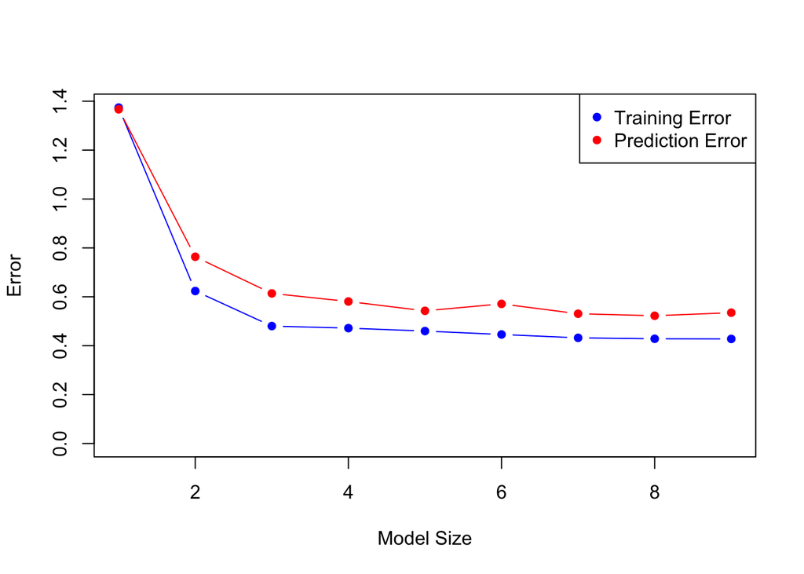

```r
# Define number of folds for cross-validation
K <- 10

# Define function to compute mean training and prediction errors
compute_errors <- function(actual, predicted) {
  train_error <- mean((actual - predicted)^2)
  pred_error <- mean((actual - predicted)^2)
  return(list(train_error = train_error, pred_error = pred_error))
}

# Initializing error vectors for each model
train_errors <- rep(0, 9)
pred_errors <- rep(0, 9)

# Performing cross-validation for each model
for (i in 1:length(model_sizes)) {
  predictors <- optimal_predictors[[i]]
  train_errors_cv <- rep(0, K)
  pred_errors_cv <- rep(0, K)

  # Performing K-fold cross-validation
  for (j in 1:K) {
    # Splitting data into training and validation sets
    set.seed(j)
    folds <- sample(1:K, nrow(prostateCancer), replace = TRUE)
    train_data <- prostateCancer[folds != j, ]
    val_data <- prostateCancer[folds == j, ]

    # Fitting model on training data
    formula <- as.formula(paste0("lcavol ~ ", paste(predictors, collapse = " + ")))
    fit <- glm(formula, data = train_data)

    # Predictions on validation data
    actual_val <- val_data$lcavol
    predicted_val <- predict(fit, newdata = val_data)

    #predicting on training data
    actual_train <- train_data$lcavol
    predicted_train <- predict(fit, newdata = train_data)

    # Computing errors
    train_error <- mean((actual_train - predicted_train)^2)
    pred_error <- mean((actual_val - predicted_val)^2)
    train_errors_cv[j] <- train_error
    pred_errors_cv[j] <- pred_error
  }

  # Computing mean training and prediction errors
  train_errors[i] <- mean(train_errors_cv)
  pred_errors[i] <- mean(pred_errors_cv)
}

# Plotting errors as a function of model size

plot(model_sizes, train_errors, type = "b", pch = 16, col = "blue", ylim = c(0, max(train_errors, pred_errors)), xlab = "Model Size", ylab = "Error")
points(model_sizes, pred_errors, type = "b", pch = 16, col = "red")
legend("topright", legend = c("Training Error", "Prediction Error"), pch = 16, col = c("blue", "red"))
```

## Exercise 5: Conclusion

```r
best_model_idx = which.min(abs(tail(train_errors,8) - tail(pred_errors,8)))
best_predictors <- optimal_predictors[[best_model_idx + 1]]

formula <- as.formula(paste0("lcavol ~ ", paste(best_predictors, collapse = " + ")))
best_model <- lm(formula, data = prostateCancer)

summary(best_model)
```

```
##
## Call:
## lm(formula = formula, data = prostateCancer)
##
## Residuals:
##      Min       1Q   Median       3Q      Max
## -1.92180 -0.49945 -0.09019  0.58214  2.01844
##
## Coefficients:
##             Estimate Std. Error t value Pr(>|t|)
## (Intercept) -1.21022    0.68213  -1.774   0.0793 .
## age          0.02003    0.01033   1.939   0.0556 .
## lbph        -0.08935    0.05352  -1.669   0.0984 .
## lcp          0.30907    0.06175   5.006 2.67e-06 ***
## lpsa         0.54273    0.07580   7.160 1.93e-10 ***
## ---
## Signif. codes:  0 '***' 0.001 '**' 0.01 '*' 0.05 '.' 0.1 ' ' 1
##
## Residual standard error: 0.6984 on 92 degrees of freedom
## Multiple R-squared:  0.6635, Adjusted R-squared:  0.6488
## F-statistic: 45.35 on 4 and 92 DF,  p-value: < 2.2e-16
```